# gbm and RandomForest

Teaching Staff

2023-03-10

## Basic Implementations

### Data

We’ll use a common dataset that contains information on 2,930 properties in Ames, Iowa.

```r
# install.packages("modeldata")
data(ames, package = "modeldata")
head(ames)
```

```
##                           MS_SubClass                MS_Zoning Lot_Frontage
## 1 One_Story_1946_and_Newer_All_Styles  Residential_Low_Density          141
## 2 One_Story_1946_and_Newer_All_Styles Residential_High_Density           80
## 3 One_Story_1946_and_Newer_All_Styles  Residential_Low_Density           81
## 4 One_Story_1946_and_Newer_All_Styles  Residential_Low_Density           93
## 5            Two_Story_1946_and_Newer  Residential_Low_Density           74
## 6            Two_Story_1946_and_Newer  Residential_Low_Density           78
##   Lot_Area Street           Alley          Lot_Shape Land_Contour Utilities
## 1    31770   Pave No_Alley_Access Slightly_Irregular          Lvl    AllPub
## 2    11622   Pave No_Alley_Access            Regular          Lvl    AllPub
## 3    14267   Pave No_Alley_Access Slightly_Irregular          Lvl    AllPub
## 4    11160   Pave No_Alley_Access            Regular          Lvl    AllPub
## 5    13830   Pave No_Alley_Access Slightly_Irregular          Lvl    AllPub
## 6     9978   Pave No_Alley_Access Slightly_Irregular          Lvl    AllPub
##   Lot_Config Land_Slope Neighborhood Condition_1 Condition_2 Bldg_Type
```

[output cut: 83 more lines]

```r
set.seed(123)
## Get a random split of 70% for training data
split = sample(nrow(ames), nrow(ames)*.7, replace = F)
train = ames[split,]
test = ames[-split,]
```

## gbm

### Basic Implementation

We have two functions in gbm. `gbm::gbm` takes a formula interface. `gbm::gbm.fit` takes a matrix interface similar to glmnet.

```r
set.seed(123)

m1 = gbm(
  formula = Sale_Price ~ ., # use all predictors
  distribution = "gaussian",
  data = train,
  n.trees = 1000,
  interaction.depth = 1,
  shrinkage = 0.001,
  cv.folds = 5,
  n.cores = NULL,
  verbose = FALSE # setting this to true will give a lot of model info
)
```

We can see our model fit

```r
print(m1)
```

```
## gbm(formula = Sale_Price ~ ., distribution = "gaussian", data = train,
##     n.trees = 1000, interaction.depth = 1, shrinkage = 0.001,
##     cv.folds = 5, verbose = FALSE, n.cores = NULL)
## A gradient boosted model with gaussian loss function.
## 1000 iterations were performed.
## The best cross-validation iteration was 1000.
## There were 73 predictors of which 7 had non-zero influence.
```

### Computing MSE and RMSE

```r
sqrt(min(m1$cv.error))
```

```
## [1] 59062.11
```

```r
min_mse = which.min(m1$cv.error)
min_mse
```

```
## [1] 1000
```

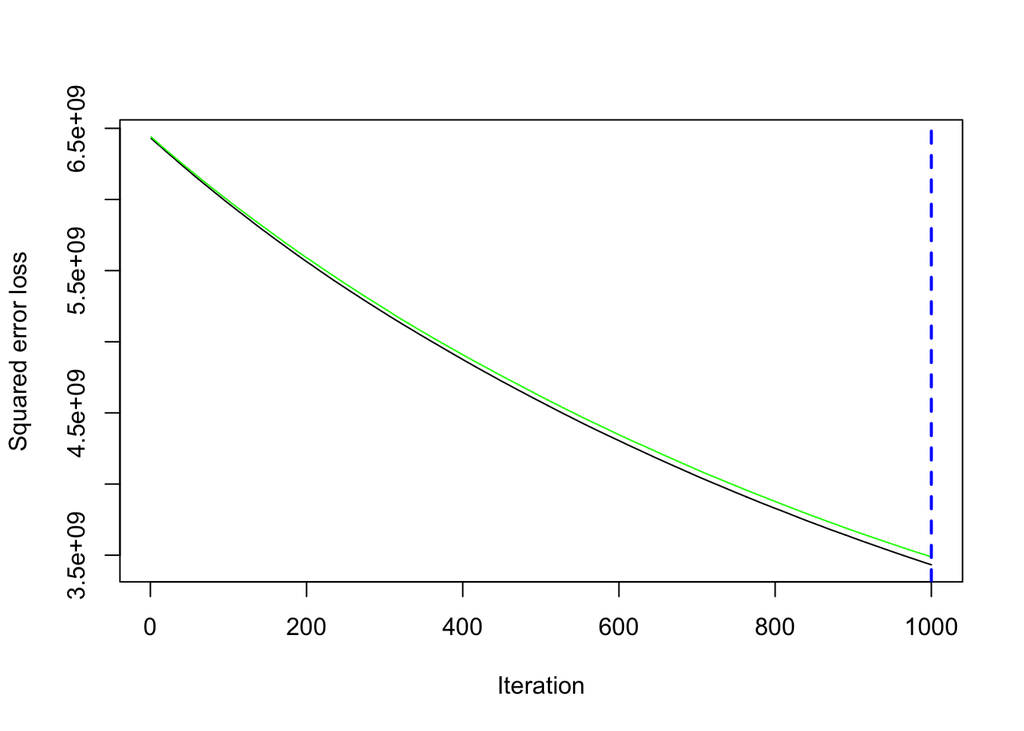

```
## [1] 1000
```

```r
## plot loss function as a result of n trees
gbm.perf(m1, method = "cv")
```

### Tuning

The defaults generally suck. We can tune parameters one at a time, but we can also perform a grid search which will iterate over multiple combinations of hyperparameters.

```r
## Make a grid
grid = expand.grid(
  shrinkage = c(0.05, 0.1),
  interaction.depth = c(5,7),
  n.minobsinnode = c(5,7),
  bag.fraction = c(.65, .8),
  optimal_trees = 0, # variable to store results
  min_RMSE = 0 # variable to store results
)

nrow(grid)
```

```
## [1] 16
```

```r
head(grid)
```

```
##   shrinkage interaction.depth n.minobsinnode bag.fraction optimal_trees
## 1      0.05                 5              5         0.65             0
## 2      0.10                 5              5         0.65             0
## 3      0.05                 7              5         0.65             0
## 4      0.10                 7              5         0.65             0
## 5      0.05                 5              7         0.65             0
## 6      0.10                 5              7         0.65             0
##   min_RMSE
## 1        0
## 2        0
## 3        0
## 4        0
## 5        0
## 6        0
```

```r
## Randomize our data to avoid an algorithmic problem
idx = sample(1:nrow(train), nrow(train))
r_ames = train[idx,]

## Do a grid search
for(i in 1:nrow(grid)){
  ## set a seed for reproducibility (not required)
  set.seed(123)
  ## train a model
  m = gbm(
    formula = Sale_Price ~.,
    distribution = "gaussian",
    data = r_ames,
    n.trees = 200,
    interaction.depth = grid$interaction.depth[i],
    shrinkage = grid$shrinkage[i],
    n.minobsinnode = grid$n.minobsinnode[i],
    bag.fraction = grid$bag.fraction[i],
    cv.folds = 5,
    n.cores = NULL,
    verbose = FALSE
  )

  ## Update minimum training error and trees to grid
  grid$optimal_trees[i] = which.min(m$cv.error)
  grid$min_RMSE[i] = sqrt(min(m$cv.error))
}
```

This will take a long time to run but suffice it to say we will get a bunch of models and then pick our best one.

```r
## Get best hyperparameters
bestRow = which.min(grid$min_RMSE)
bestRow
```

```
## [1] 10
```

```r
set.seed(123)

final = gbm(
  formula = Sale_Price ~.,
  distribution = "gaussian",
  data = train,
  n.trees = 1000,
  interaction.depth = grid$interaction.depth[bestRow],
  shrinkage = grid$shrinkage[bestRow],
  n.minobsinnode = grid$shrinkage[bestRow],
  bag.fraction = grid$shrinkage[bestRow],
  cv.folds =  5,
  n.cores = NULL,
  verbose = FALSE
)
```

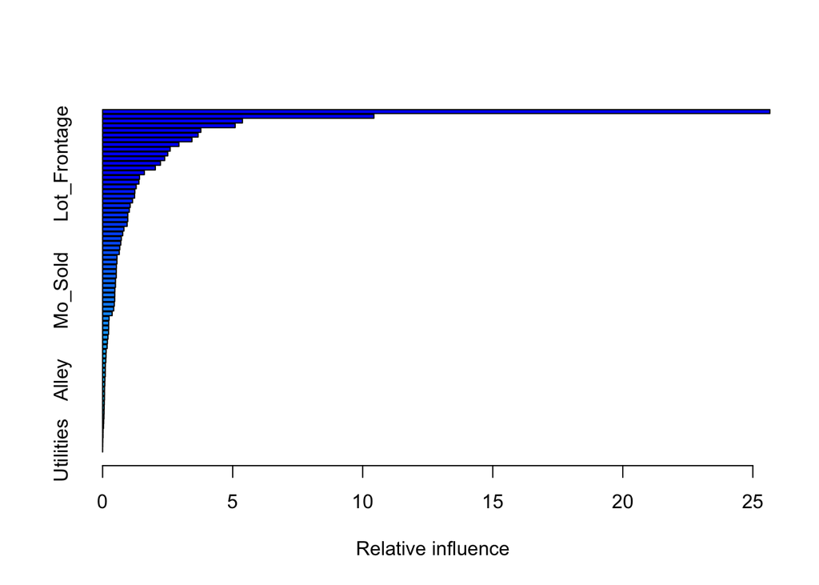

```
##                                   var      rel.inf
## Neighborhood             Neighborhood 25.654317478
## Gr_Liv_Area               Gr_Liv_Area 10.430843273
## First_Flr_SF             First_Flr_SF  5.376050117
## Total_Bsmt_SF           Total_Bsmt_SF  5.096327368
## Lot_Area                     Lot_Area  3.776657063
## MS_SubClass               MS_SubClass  3.672191624
## Garage_Area               Garage_Area  3.433989635
## Exterior_2nd             Exterior_2nd  2.933962130
## TotRms_AbvGrd           TotRms_AbvGrd  2.598279734
## Year_Built                 Year_Built  2.505757698
## Exterior_1st             Exterior_1st  2.387713174
## Lot_Frontage             Lot_Frontage  2.224433339
## Year_Remod_Add         Year_Remod_Add  2.026713692
## Open_Porch_SF           Open_Porch_SF  1.604735348
## Second_Flr_SF           Second_Flr_SF  1.418384035
## Sale_Condition         Sale_Condition  1.396094010
## Mas_Vnr_Area             Mas_Vnr_Area  1.291687259
## Bsmt_Exposure           Bsmt_Exposure  1.239745807
## Bsmt_Unf_SF               Bsmt_Unf_SF  1.229555475
## Bsmt_Full_Bath         Bsmt_Full_Bath  1.150546556
## Wood_Deck_SF             Wood_Deck_SF  1.059313052
## Pool_Area                   Pool_Area  1.027053924
## Garage_Cars               Garage_Cars  0.967767404
## Overall_Cond             Overall_Cond  0.966851086
## Pool_QC                       Pool_QC  0.943033860
## BsmtFin_Type_1         BsmtFin_Type_1  0.820358614
## Longitude                   Longitude  0.772746658
## Roof_Style                 Roof_Style  0.720190457
## Fireplaces                 Fireplaces  0.699972640
## Latitude                     Latitude  0.659535220
## Lot_Shape                   Lot_Shape  0.639727536
## Condition_1               Condition_1  0.552694176
## MS_Zoning                   MS_Zoning  0.550656088
## Three_season_porch Three_season_porch  0.531209688
## Screen_Porch             Screen_Porch  0.526569037
## Functional                 Functional  0.524576736
## Land_Contour             Land_Contour  0.495815386
## Land_Slope                 Land_Slope  0.494273940
## Mo_Sold                       Mo_Sold  0.471065509
```

[output cut: 19 more lines]

```
## Garage_Finish           Garage_Finish  0.083093345
## Electrical                 Electrical  0.073536877
## Exter_Cond                 Exter_Cond  0.073438757
## BsmtFin_SF_2             BsmtFin_SF_2  0.071211069
## Half_Bath                   Half_Bath  0.065039604
## Central_Air               Central_Air  0.059339674
## Paved_Drive               Paved_Drive  0.055884400
## Bsmt_Half_Bath         Bsmt_Half_Bath  0.051713746
## Condition_2               Condition_2  0.041661311
## Misc_Val                     Misc_Val  0.033479001
## Kitchen_AbvGr           Kitchen_AbvGr  0.018850890
## Bldg_Type                   Bldg_Type  0.017017299
## BsmtFin_SF_1             BsmtFin_SF_1  0.006322851
## Street                         Street  0.003378557
## Utilities                   Utilities  0.000000000
```

```r
summary(final)
```

### Predict Values on Test Data

```r
predictions = predict(final, n.trees = final$n.trees,
                      test)

### Test RMSE
sqrt(mean((test$Sale_Price - predictions)^2))
```

```
## [1] 28021.43
```

## Random Forests

```r
## A default Random Forest Implementation

set.seed(123)

rfm1 = randomForest(
  formula = Sale_Price ~.,
  data = train
)
```

We can get metrics directly from this model

```r
## number of trees in the best model
which.min(rfm1$mse)
```

```
## [1] 424
```

```r
### Get MSE
rfm1$mse[which.min(rfm1$mse)]
```

```
## [1] 724460090
```

```r
## If we want RMSE
sqrt(rfm1$mse[which.min(rfm1$mse)])
```

```
## [1] 26915.8
```

### Tuning

Random Forests only have a handful of parameters. We can tune the number of trees (`ntree`), the number of variables to randomly sample at each split (`mtry`). When `mtry = p`, we are perform bagging. When `mtry = 1` we are performing completely random split. Don’t do this. Start with ~5 values evenly split from 2 to p.

```r
## suppose
p = 12
seq(2, 12, 6)
```

```
## [1] 2 8
```

We can also mess around with the node size, the minimum number of samples within terminal nodes, and the maxnodes.

Annoyingly, randomForest makes grid search a pain because it does not scale well due to its implementation. As a result, we might try using the `ranger` package instead.

```r
## Since this is an example, I purposely use a samll number
## in the grid
grid2 = expand.grid(
  mtry       = seq(20, 30, by = 2),
  node_size  = seq(3, 9, by = 2),
  samp_size = c(.55, .632, .70, .80),
  OOB_RMSE   = 0
)

nrow(grid2)
```

```
## [1] 96
```

Now we can perform a similar type of loop as before

```r
for(i in 1:nrow(grid2)){

  rangModel = ranger(
    formula = Sale_Price ~ .,
    data = train,
    num.trees = 500,
    mtry = grid2$mtry[i],
    min.node.size = grid2$node_size[i],
    sample.fraction = grid2$samp_size[i],
    seed = 123
  )

  ## Update OOB error
  grid2$OOB_RMSE[i] = sqrt(rangModel$prediction.error)
}
```

We identify our model in similar fashion to gbm in that we find the best hyperparameters, fit that as our final model and then test against our predictions.

```r
bestRow2 = which.min(grid2$OOB_RMSE)
bestRow2
```

```
## [1] 74
```

```r
final = ranger(
    formula = Sale_Price ~ .,
    data = train,
    num.trees = 500,
    mtry = grid2$mtry[bestRow2],
    min.node.size = grid2$node_size[bestRow2],
    sample.fraction = grid2$samp_size[bestRow2],
    seed = 123
  )

pred_rf <- predict(final, test)
sqrt(mean((test$Sale_Price - pred_rf$predictions)^2))
```

```
## [1] 26992.79
```

## Where could you go next?

If you’re going to use R in production or doing this for real I strongly recommend checking out the `mlr3`, `xGBoost`, `h20`, and `tidymodels` packages.